# 研究诚信

对自己的科研负责的关键在于遵循良好的**研究规范**。好的研究规范可以通过专业化的标准来尽可能地保证我们的研究质量和可信性。通常情况下，人们对于研究规范的标准并不会世殊时异。然而，大部分的研究标准都受到社会、政治和技术因素的影响。例如，共享你的研究报告中的所有数据逐渐被视为一种良好的研究规范。在互联网出现之前，这很难实现，但现在网上有了免费数据储存库的存在，这已经变得容易多了。因此，我们越来越多地看到,研究资助方希望尽可能公开使用其资助收集到的数据。

**研究诚信**与**研究伦理**是有所区别的。研究诚信是基于专业标准制定的一组原则。而研究伦理则是遵循一系列道德原则，如自主性、利他性、无害原则和公正性[@gillon_medical_1994]。自主性原则引导了诸如知情同意、对参与者的如实告知以及保密等研究措施。根据无害原则，研究者应避免进行可能对参与者造成伤害或负担过重的研究[@varkey_principles_2021]。

研究诚信行为守则中的专业标准在不同的文件当中可能会略有不同[@komic_research_2015]。本章将讨论[欧洲研究诚信行为守则](https://en.wikipedia.org/wiki/Nuremberg_Code) 以及[荷兰研究诚信行为守则](https://www.nwo.nl/en/netherlands-code-conduct-research-integrity)。在这个章节里，研究诚信行为守则将被简写为’行为守则’。你可能需要遵守其他的行为准则，这取决于你在哪里工作。

欧洲行为守则指出，“研究界的一个基本责任是制定研究原则，为恰当研究行为设定标准，最大限度地提高研究的质量和可靠性, 并对研究诚信受到的威胁或违规行为做出充分的应对。”行为守则并非一成不变，因为我们所认为的“恰当研究行为”也会随着时间的推移而变化。然而所有研究诚信行为准则都有一些核心原则，如诚实、公开、谨慎、负责、可靠、尊重和独立。这些基本原则被转化为更具体的行为，这些行为被认为是恰当的行为——无论是对研究人员还是对研究机构。你是否曾阅读过所在机构的相关行为守则?如果没有的话，您所在的机构可能已经违反了相关的守则，因为他们忽略了“开展适当和充足的伦理和研究诚信培训,以确保所有相关人员了解相关守则和法规”的责任。

荷兰研究诚信行为守则要求“开展具有科学、学术和/或社会意义的研究”。当然，你可能纯粹出于**教育**目的进行一项研究，因此你所进行的研究不需要任何额外的价值(尽管它总是很好的)。但研究人员应避免进行几乎没有价值的研究，造成**研究浪费**。Chalmers和Glasziou[-@chalmers_avoidable_2009]讨论了四种造成无效研究的可能：选择错误的研究问题、进行没有必要的或不恰当的实验研究(这就是为什么你需要评估你将收集的信息的价值，正如在样本大小证明)一章中所解释的那样)、不及时或根本不报告研究结果(正如偏倚一章所解释的那样),以及带有预设的或无法使用的研究报告(可以通过报告你的研究来预防，以便将来纳入C分析)。荷兰行为守则还明确要求研究人员“确保研究设计能够回答研究问题”。因此，本书所讨论的许多主题都与避免无效研究有关，而这也关乎于研究诚信。

正如前文所述，研究人员应尽可能分享他们的数据，这也是行为守则的要求：“在研究完成后，尽可能公开研究结果和研究数据。否则请解释不披露的正当原因”。如下所述，《通用数据保护条例》(General Data Protection Regulation, GDPR)要求欧洲研究人员在共享所收集的数据时获得许可。以前的知情同意书中并未考虑此类问题，甚至通常要求在超出规定时间后销毁数据。这是一个关于专业标准随时间改变的典型例子，因为目前人们通常期望在发表文章的同时永久保留相关数据。因此，您需要确保使用最新的同意书，允许您分享所收集的数据。

青年研究人员有时会感觉发现他们的导师要求他们做一些违反行为守则的事情。虽然并非所有的研究人员会屈服于这样的压力，但也有些人明确表示他们会做出违反行为守则的事情只要能尽快的获得博士学位[@van_de_schoot_use_2021]。有些研究人员会信任他们的导师，相信导师知道做什么是正确的，即使导师自己可能会被他们的上级迫使去违反行为准则。毫无疑问，向你所管辖的人施压让他们违反行为准则，本身就构成了对行为准则的违反。正如荷兰行为守则规定：“导师、项目负责人、研究主管等人在履行职务时，应避免采取任何可能使研究人员无视或忽略守则规定的行动。”

一些研究员发现，科学领域对研究基金的激烈竞争，以及根据发表文章数量进行的个人奖励，可能导致出现不道德的行为[@edwards_academic_2017; @anderson_perverse_2007]。针对这种情况，荷兰的行为准则特别强调了建立一个开放、安全且包容的研究文化的重要性，在这样的环境中，研究员可以自由讨论这些压力，以及如何保证始终遵循良好的研究实践。如果您发现并想要报告违反行为准则的可疑行为，通常您可以向大学或其他机构的保密顾问寻求帮助。有时，甚至可以通过像[SpeakUp](https://peopleintouch.com/)这样的服务，匿名举报这些可疑的行为。在此，我们强烈建议，为了科学的公正性和您自身的发展，如果您遇到任何问题或不当行为，一定要寻求您信任的人（例如保密顾问）进行讨论和咨询。

如果做正确的事情总是如此简单，那么就不会有研究人员违反行为守则的问题。违反行为守则可能会立刻带来个人利益，比如更可能在高影响力期刊发表论文，但这种行为对于科学研究的可靠性产生了长期的负面影响，同时也可能会削弱公众对科学的信任[@wingen_no_2020; @anvari_replicability_2018]。社会科学家可能会将这种情况视为一种社会困境，即个体的最优选择与集体的最优选择存在冲突。奖赏结构的改变可能有助于使个体和集体的利益更加一致。有一种方式是找出并处罚那些故意违反行为守则的研究人员（例如，关于[Brian Wansink](https://www.vox.com/science-and-health/2018/9/19/17879102/brian-wansink-cornell-food-brand-lab-retractions-jama)的案例）。新的偏倚检测工具，如*p*曲线和*z*曲线分析，也可以用来识别那些系统性地使用可疑研究实践的研究人员（我们将在下一部分进一步讨论这个问题）。最后，尽管这听起来可能有些理想化，但我坚信所有的科学家都应将科学的利益放在首位。如果你在公立大学从事科学研究，你的工资是由纳税人支付的，目的是创造可靠的知识。在追求其他目标（如成功的职业生涯）时，你的任何行为都不应妨碍你履行社会赋予你的责任，即产生可靠和可信的知识。

## 15.1 可疑的研究行为

理论上，所有研究人员都应遵循诚信的研究行为准则，但实际上并非所有人都能做到。许多来自不同学科的研究人员都承认可能进行过被称为“可疑研究行为”的操作。这种说法或许有些保守，因为这些行为并非仅仅值得质疑，而是直接违反了行为准则。然而，这些行为之所以被称为“可疑”，主要是因为许多研究人员并未充分认识到这些行为的问题所在，也未能完全理解问题的严重性。 所谓的“可疑研究行为”通常指违反了行为准则的规定：“确保研究方法的选择、数据分析、结果的评估和可能的解释，不受非科学或非学术因素（例如，商业或政治利益、观点或偏好）的影响。”除了商业或政治外，许多研究人员也迫于论文发表以及职位晋升的压力。一些小手段可以使科研论文发表更容易，因为这些技巧可以增加结果的显著性或者掩盖研究的缺陷，使结果看起来更有说服力。那么，代价是什么呢？代价便是科研的真实性和诚信。

尽管荷兰和欧洲行为准则规定研究人员应同等地对待和发表所有研究结果，包括阳性结果和阴性结果，但许多研究人员仍选择性地只报告那些有显著结果的研究或分析。在发布显著结果时，注册报告已经成为使研究实践与行为准则一致的重要一步。

研究人员有时会过于灵活地使用实验变量、测量手段、协变量以及采取其他一系列数据分析策略来分析他们的数据。这样做虽然可以提高统计显著结果的可能性，但也会增加第一类错误的发生率。预注册已经成为提高科学文章中报告的分析中数据驱动选择的透明度的重要步骤，它允许研究人员评估统计分析计划的任何偏差是否会降低或增加检验的严谨性[@lakens_value_2019]。随着越来越多人意识到这些错误做法的问题本质，我们希望这些错误的做法能大幅下降，与此同时研究人员也能学习到正确的方法，在处理数据中维持一定的灵活性（例如，通过序列分析来代替可选的停止）。@wigboldus_encourage_2016在可疑的研究行为和可疑的报告行为之间做出了重要区分。无论何时有疑虑，公开透明地说明分析数据时所做的决定可以为研究人员提供他们需要的所有信息来评估报告的结果。

参与可疑研究实践的自我承认,至少从研究人员的各种样本中进行14次调查。

图 15.1:在研究人员的各种样本中至少从14项调查中至少一次参与可疑研究实践的自我承认。

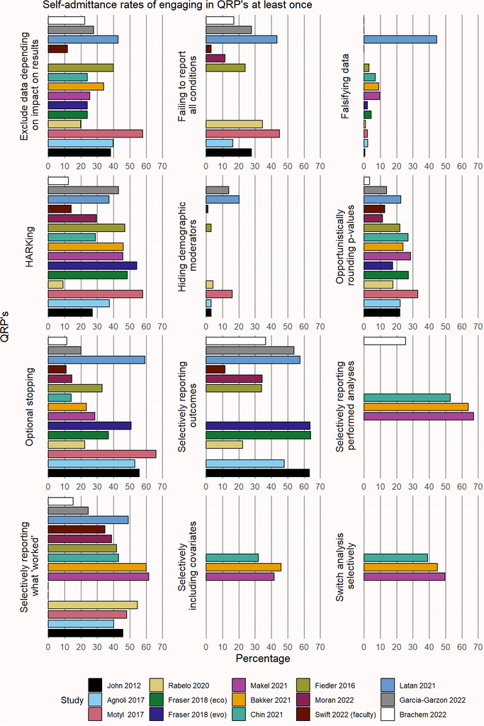

## 15.2 捏造、伪造和抄袭

除了可疑的研究活动之外，捏造数据是编造结果并把它们当作真实的记录，而伪造是在没有任何科学依据的情况下操纵研究的各个方面，包括数据。伪造数据是一种极端不诚实的研究行为。研究人员在数十项实验中制造了完整的数据集的[案例数量很大](https://en.wikipedia.org/wiki/List_of_scientific_misconduct_incidents)。 一些例子已经在偏倚检测的那一章提到过。伪造很难发现，因为通常研究人员通常在数据收集时保持错误的记录。例如，Susannah Cahalan在她的《[伪装者](https://www.npr.org/2019/11/13/777172316/the-great-pretender-investigates-a-landmark-moment-in-psychiatric-history)》一书中提出了一个有力的论点，即David Rosehan的著名研究“[在疯狂的地方保持理智](https://en.wikipedia.org/wiki/Rosenhan_experiment#Accusation_of_hoax)”很大程度上是虚构的。在这项研究中，假装听到声音的健康同伙被接纳为患有精神分裂症的住院病人。她的详细调查对该研究是否按照描述的进行提出了严重的质疑（参见@scull_rosenhan_2023）。

人们可能希望篡改和伪造数据的情况是很少见的，但最近在荷兰进行的一项大规模调查显示，这种情况的发生的概率约为4%[@gopalakrishna_prevalence_2022]。数据伪造也可能在局部的范围内发生。想象你正在为一项研究收集数据。作为研究的一部分，你的任务是询问参与者的年龄和性别，以便在描述样本时报告人口统计数据。在收集完所有数据后，你发现遗漏了两名被试的相关数据。因此你可能凭借你依稀的记忆来猜测这两名被试的年龄和性别，以免在统计人口信息时暴露你在数据收集过程中犯了错误。然而，这当然也算伪造数据。你本应开诚布公。每个人都会犯错，重要的是要建立一个可以容忍错误的科研氛围，这样我们就可以以史为鉴，防止未来再次出现这样的错误[@bishop_fallibility_2018]。

请注意，**模拟**数据进行功效分析是可接受的，只是不能将这样的数据当作是从真实参与者那里收集的数据。荷兰行为准则规定：“不得伪造数据或研究结果，也不得将伪造的材料报告为事实。要公正的对待对所有获得的研究结果。不得在没有明确和适当的理由的情况下删除或更改结果。在数据分析过程中，不得添加伪造的数据。”

欧洲行为准则将剽窃定义为：“使用他人的工作和想法，而不给出原始文献的引用，从而侵犯了原作者的知识产权。”可以使用别人的内容，但应注明来源，并用引号标出文本是从另一个来源引用的。剽窃的一个特殊情况是’自我剽窃’或者说循环使用文本，即同一作者在不同的文章中使用相同的文本内容。可以预见的是对于这种做法是否存在问题还存在分歧[@bird_self-plagiarism_2008]，因为总会有一些学者有不同的意见。总的来说，研究人员不应该仅为了增加他们的文章数量就重新使用之前大部分的工作并将其作为新的工作。但是，许多研究人员认为，如果需要在新的论文中表达相同的信息，那么重新使用方法部分的描述是完全可以接受的[@pemberton_text_2019]。出版道德委员会(COPE)的指导方针也有类似的[表述](https://publicationethics.org/text-recycling-guidelines)：

这些指导方针涵盖了如何处理提交的稿件和已发表文章中的文本循环使用问题，并指出可接受文本循环使用以及不太可能接受的情况。例如，在研究论文的方法部分有重复内容（指的是先前使用的方法），并引用原始文章，可能是完全适当的。然而，未公开的部分重复，或者在结果、讨论或结论中的重复使用，都不太可能被接受。

因此，当研究人员为了让自己看起来更有研究成效而多次发表非常相似的内容时，自我抄袭就被认为是有问题的。

除了伪造、篡改、剽窃等可疑研究行为外，还存在一些其他的问题研究行为。@gopalakrishna_prevalence_2022还认为，诸如对初级研究人员的指导或监督不足，不公平地审查文章或基金、研究记录不充分等行为都是有问题的做法。

## 15.3 知情同意和数据隐私

在公共空间内进行自然观察之外的研究时，应先获得被试的同意。在数据收集之前，最重要的是被试阅读和签署的关于研究伦理和数据隐私的同意书。同意书解释了研究的目的，强调参与是自愿的，参与者可以在他们想要的时候停止，解释了任何风险和好处(如报酬)，告知他们有关数据隐私问题，并详细说明了参与者在研究中有任何问题可以联系谁。

开放数据很重要——但在公共仓库中共享数据时，保护数据隐私同样至关重要。这意味着在公开共享数据之前，需要从数据集中删除所有有关个人身份标识的信息（如姓名、IP地址、被试的ID号码等）。如果您使用版本控制系统，请确保您分享的数据文件的初始版本中不存在任何识别信息，因为其他用户不仅可以访问文件的最新版本，还可以查看完整的文件历史记录。有关GDPR和研究的详细概述，请参阅格罗宁根大学（ [Groningen University](https://www.rug.nl/digital-competence-centre/privacy-and-data-protection/gdpr-research/) ）的相关信息。

## 利益冲突

单纯的利益冲突并不违反行为准则，只要研究人员对此保持透明即可。欧洲行为准则规定：“所有作者必须披露任何利益冲突，以及对研究或发表其结果的经济或其他类型的支持。”当你审查同行的科学工作，例如基金申请提案或科学文章时，也可能会出现利益冲突。在这里私人关系可能会成为利益冲突，要么是因为你与一位研究人员是非常亲密的朋友，要么是因为你觉得另一位研究人员是敌对者或竞争对手。在这些情况下，你应该再次声明你的利益冲突，期刊编辑或基金审查小组通常会尝试去找另一名审稿人。

## 研究伦理

在你进行研究之前，大多数机构会要求你获得**伦理审查委员会**(ERB)的许可，它有时也被称为机构审查委员会（IRB）。特定类型的研究可能会由专门的委员会进行审查。例如医学研究由医学伦理审查委员会（METC）审查，动物研究由动物伦理委员会审查。伦理审查的目的是平衡以下两个目标：保护被试，使研究有益于社会[@whitney_balanced_2016]。《赫尔辛基宣言》为评估人类受试者参与的研究提供了重要依据。它强调了个体的自主权，以及参与或停止参与研究的知情同意权。

《赫尔辛基宣言》建立在《纽伦堡法典》[Nuremberg Code](https://en.wikipedia.org/wiki/Nuremberg_Code)的基础上，后者是二战后制定的一套道德原则，旨在回应纳粹医生未经同意对集中营中的受监禁者进行的不道德研究（关于这种不道德研究是否可以使用和引用的道德讨论参见 @caplan_how_2021 和 @moe_should_1984）。 另一个对人体进行不道德实验的例子是塔斯克吉梅毒研究[Tuskegee syphilis study](https://en.wikipedia.org/wiki/Tuskegee_Syphilis_Study)该研究纳入了400名患有梅毒的非裔美国男性，以检验这种疾病在未经治疗时的影响。被纳入研究的男性没有同意不接受治疗，也没有得知对他们疾病的诊断。这项研究最终持续了40年。尽管在大学进行的大多数研究的有害风险要低得多，但相较于其对科学的益处，评估研究对被试可能造成的危害仍然很重要。研究人员可能会展示负面刺激或要求被试记住他们在研究中经历的负面事件，这些事件仍然会有伤害性风险。在设计研究时可能有同样有效的替代方案，仍然可以让研究人员回答他们的研究问题。除了防止伤害之外，研究人员还必须告知被试有关研究的情况，并征得他们的同意。知情同意书中的信息应真实。如果有必要在知情同意书中就他们将要进行的研究向被试撒谎（例如被试认为他们将与其他被试互动，但这些人实际上是研究人员的同谋和研究的一部分），那么研究人员应该在数据收集完成后，进行**事后情况说明**。研究人员还应为被试**保密**。如果研究者计划在公共数据库中共享数据，在收集开放性问题时应尤其注意。

## 测试自己

**问题1**：请尝试用一句话来定义”捏造数据”。这句话的开头可以是”捏造数据的方式有很多，比如说……“。你的定义应该包括所有形式的不诚实的捏造数据，但不应该包括诚实的形式，比如*模拟*数据集。

**问题2**：想象一下，你正在分析你的数据，在使用电脑进行的一项实验中，一名被试在一个输入文本的问题中把年龄输入为117岁。虽然达到这个年龄不是不可能的，但被试更有可能是想输入17这个值。应该把这个值改成17吗？现在想象一下，你已经用你电脑上的系统时钟测量了人们浏览一个网站的时间（以秒为单位），极其准确，在时间测量上完全可靠。这项研究有一个实验条件和一个控制条件。两组间差异无统计学意义。但是如果你将一个在控制条件下的被试的数据从117秒更改为17秒，组间的差异在统计学上是显著的，将证实你在设计实验时做出的假设。

这两种情况有什么不同呢？为什么117秒到17秒的时间记录违反了科研诚信的行为准则？荷兰科研诚信行为准则有整整三个自然段在阐述这一问题。如果你将这一位被试的年龄从117更改为17后写下被试的平均年龄，当这个数字是基于你更改的数据时，除了”被试的平均年龄为20.4岁”这一声明之外，你还需要提供什么？

**问题3**: 有时报告结果，其余时候不报告结果的做法被称为**选择性报告**。说到选择性报告，最重要的还是在于研究者的意图。不报告一项有缺陷的研究可能是有意义的（例如实验中存在编程错误，或者所有被试都误解了指导语，提供了无用的输入）。不广而告之地报告一项设计有问题的研究也可能是有道理的——例如，你认为一项操作会产生特定的效果，但该操作并没有达到预期的效果。然而，即使是这样的数据也可能对其他人有用，知道你认为会产生特定效果的操作没有效果，可能会防止其他人在未来犯同样的错误。如果以某种方式分享这样的结果，至少有时对科学是有益的。但是正如我们下面将看到的，研究人员也会根据结果是否在统计学意义上显著而选择性地报告研究。

一位科学家进行了几项实验，但只分享了那些在看完结果后得出了支持他们假设的结果的实验。这位科学家从不分享那些不能支持他们假设的实验结果。你认为这位科学家的行为在道德上是可接受的还是不可接受的？

**问题4**：一位科学家进行了几项实验，但只分享了那些在看完结果后被认为是设计良好的实验的结果。这位科学家从不分享那些在看了数据后被判定为设计不良的实验的结果。你认为这位科学家的行为在道德上是可接受的还是不可接受的？

**问题5**：一位科学家在进行一项实验时，对几个因变量进行了多种方式的分析，但只分享了那些在看了结果后得出了支持他们假设的结果的分析。这位科学家从不分享那些不能支持他们的假设的分析结果。你认为这位科学家的行为在道德上是可接受的还是不可接受的？

目前的实践是，研究人员的确在有选择性地报告研究。Franco等人 @franco_publication_2014 对一项大型的全国范围内协作的代表性调查中的106项研究进行了分析，他们发现当研究结果是效应不显著时，有31项研究没有被写完，有7项研究写完了但还没有发表，只有10项得到发表。当结果显示出统计学上显著的效应时，仅有4项研究没有被写完，有31项研究写完了但还没有发表，有56项得到发表。有明确的证据表明，研究人员选择性地报告了证实他们假设的结果，正如我们在关于偏倚的一章中讨论的那样。

Pickett和Roche最近的一项研究[-@pickett_questionable_2017]调查了公众对捏造数据和选择性报告的看法。下表总结了他们的研究结果。可以看到有很大一部分公众认为选择性报告在道德上是不可接受的（71%的人认为在道德上不可接受），大多数公众认为这样做应该有后果（比如，73%的人认为这样的研究人员应该被禁止资助）。Pickett和Roche研究中的这些百分比在多大程度上反映了你对选择性报告在道德上可接受或不可接受程度的判断？

图15.2:来自Pickett和Roche（2017）的表格，显示了公众眼中对数据伪造和捏造、选择性报告的道德判断。

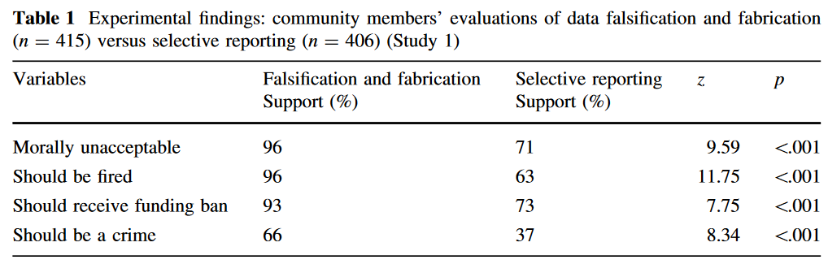

**问题7**：考虑到研究人员承认采用了有问题的研究方法，他们肯定会有一些好处。采用有问题的研究方法有什么好处？

**问题8**：采用有问题的研究方法有什么缺点？

为了改进研究方法，我们已经看到许多科学领域朝着更大的透明度迈进，包括共享数据和材料，对数据分析方式的选择的清晰化，以及预注册研究。几乎不可能预防所有的学术不端行为，但提高研究的透明度，将更容易发现有问题的研究方法，如选择性报告。同时，大学需要对相关人群进行研究伦理方面的培训，确保有让研究人员（包括你！）能够安心地做正确的事情的氛围。

## 给自己打分

在这部分作业中，你要给自己的答案打分。你可以对照下面的参考答案（提示了好的答案可能是怎样的，尽管不一定全面；你的答案可能会包含未在下面的答案中提到的正确的部分）。通读下面的答案，并为自己的答案打分。从1（非常糟糕的答案）到10（优秀的答案）。要诚实、公正。

**问题1的答案**：捏造数据的方式有很多，比如说这些数据可以被当作真实的数据，但却不是基于研究人员实际进行的真实的深入观察而来的，然而，这些数据还是被呈现为基于真实观察的数据。

*给自己打分，从1分（无答案）到10分（完美答案）。你越能指出伪造的数据看起来与真实的观察结果相似，并且它们被有意地呈现为真实的，你的分数就应该越高。*

**问题2的答案**：这两种情形的区别在于，在第二种情形下，研究人员有意产生与他们想要观察到的结果一致的结果。就荷兰研究诚信行为准则的原文而言，缺少的是”*明确和适当的理由*”。如果你报告的是基于17而不是117的平均值，你需要提供一个脚注或声明，表明你做了什么（“我们将一个年龄值117更改为17”）和这样做的理由（“因为我们强烈怀疑这个值是参与者的输入错误，实际上是17岁”）。

*给自己打分，从1分（无答案）到10分（完美答案）。你提供的答案越全面，你的分数就应该越高（能解释基于缺乏适当理由的两种情形之间的区别，具体说明荷兰研究诚信行为准则的哪个方面在第二种情形下缺失，你需要描述你改变了什么，以及改变它的理由）。*

**问题7的答案**：（1）因为他们倾向于向世界提供对他们假设的支持；（2）因为他们发表”有用”的结果比没用的结果在他们的职业生涯中获得的奖励要多得多，因此他们会把时间花在前者上；（3）即使研究人员会尝试发表这些结果，期刊也不太可能接受它们发表；（4）发表一篇故事连贯的论文更容易（只有显著的结果）。一般来说，我们可以期待有问题的研究方法在短期内为个别科学家带来好处。

*给自己打分，从1分（无答案）到10分（完美答案）。你给出的理由越多，你的分数就应该越高，包括但不限于以上三种。（译者注：应是四种）*

**问题8的答案**：对于单个科学家来说，有被同事发现、失去声誉（或者在极端情况下，失去工作）的风险。其他科学家无法复现他们的工作，也可能会影响他们的声誉。对社会来说，一个不利的方面是科学研究不像它应有的那样可靠。对科学来说，一个不利的方面可能是科学的声誉以及人们对科学的信任受到了损害。总的来说，我们可以预期，从长远来看，有问题的研究方法的成本是对于社会的。

*给自己打分，从1分（无答案）到10分（完美答案）。你给出的理由越多，你的分数就应该越高，包括但不限于以上三种。*

如果在看了这么多关于科研诚信的东西之后，你觉得需要一些东西让自己高兴起来，[这个视频](https://youtu.be/ZaNtz76dNSI)可能会有点用。